# Algorithm

Algorithm

10. Extending Tractability

WU Xiaokun 吴晓堃

xkun.wu [at] gmail

2021/12/03

## Coping with $\mathcal{NP}$-completeness

**Q**. Suppose I need to solve an $\mathcal{NP}$-complete problem. What should I do?  
**A**. Theory says you’re unlikely to find poly-time algorithm.

**Must sacrifice one of three desired features**.

- Solve problem to optimality.
- Solve problem in polynomial time.
- Solve *arbitrary instances* of the problem.

**This lecture**. Solve some special cases of $\mathcal{NP}$-complete problems.

# Finding small vertex covers

## Vertex cover

Given a graph $G = (V, E)$ and an integer $k$, is there a subset of vertices $S \subseteq V$ such that $| S | \le k$, and for each edge $(u, v)$ either $u \in S$ or $v \in S$ or both?

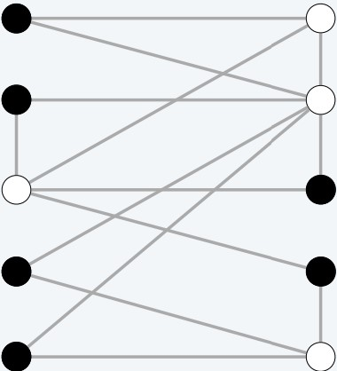

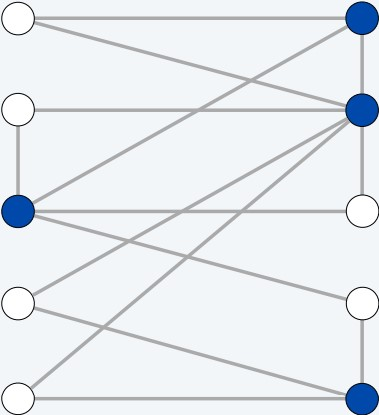

## Finding small vertex covers

**Q**. VERTEX-COVER is $\mathcal{NP}$-complete. But what if $k$ is small?

**Brute force**. $O(k n^{k+1})$.

- Try all $C(n, k) = O(n^k)$ subsets of size $k$.
- Takes $O(k n)$ time to check whether a subset is a vertex cover.

**Goal**. Limit exponential dependency on $k$, say to $O(2^k k n)$.

**Ex**. $n = 1000, k = 10$.  
**Brute**. $k n^{k+1} = 10^{34} \Rightarrow$ infeasible.  
**Better**. $2^k k n = 10^7 \Rightarrow$ feasible.

**Remark**. If $k$ is a constant, then the algorithm is poly-time; if $k$ is a small constant, then it’s also practical.

## Finding small vertex covers

**Claim**. Let $(u, v)$ be an edge of $G$. $G$ has a vertex cover of size $\le k$ iff at least one of $G - \{ u \}$ and $G - \{ v \}$ has a vertex cover of size $\le k - 1$.

**Pf**. $\Rightarrow$ Suppose $G$ has a vertex cover $S$ of size $\le k$.

- $S$ contains either $u$ or $v$ (or both). Assume it contains $u$.
- $S - \{ u \}$ is a vertex cover of $G - \{ u \}$.

**Pf**. $\Leftarrow$ Suppose $S$ is a vertex cover of $G - \{ u \}$ of size $\le k - 1$.

- Then $S \cup \{ u \}$ is a vertex cover of $G$.

**Claim**. If $G$ has a vertex cover of size $k$, it has $\le k (n - 1)$ edges.  
**Pf**. Each vertex covers at most $n - 1$ edges.

## Finding small vertex covers: algorithm

**Claim**. The following algorithm determines if $G$ has a vertex cover of size $\le k$ in $O(2^k kn)$ time.

`Vertex-Cover`($G, k$)

1. if ($G$ contains no edges) return true;
2. if ($G$ contains $\ge kn$ edges) return false;
3. let $(u, v)$ be any edge of $G$;
   1. $a$ = `Vertex-Cover`($G - \{u\}, k-1$);
   2. $b$ = `Vertex-Cover`($G - \{v\}, k-1$);
4. return ($a$ or $b$);

**Pf**.

- Correctness follows from previous two claims.
- There are $\le 2^{k+1}$ nodes in the recursion tree; each invocation takes $O(kn)$ time.

## Finding small vertex covers: recursion tree

$$T(n,k) = \left\{ \begin{array}{ll}
c & \text{if}\ k = 0 \\
cn & \text{if}\ k = 1 \Rightarrow T(n,k) \le 2^k ckn \\
2T(n,k-1) + ckn & \text{if}\ k > 1 \\
\end{array}\right.$$

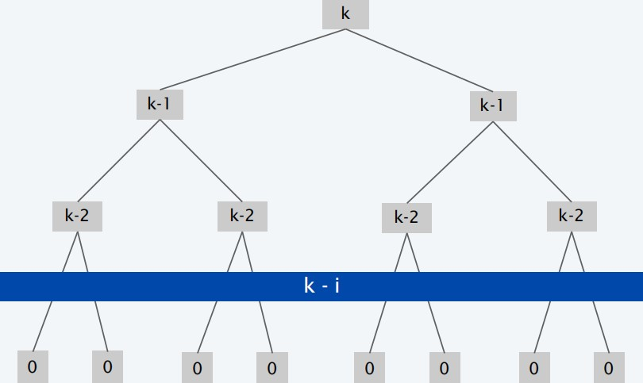

# Solving NP-hard problems on trees

## Independent set on trees

**Independent set on trees**. Given a *tree*, find a max-cardinality subset of nodes such that no two are adjacent.

**Fact**. A tree has at least one node that is a leaf (degree = 1).

**Key observation**. If node $v$ is a leaf, there exists a max-cardinality independent set containing $v$.

**Pf**. [exchange argument]

- Consider a max-cardinality independent set $S$.
- If $v \in S$, we’re done.
- Otherwise, let $(u, v)$ denote the lone edge incident to $v$.
  - if $u \notin S$ and $v \notin S$, then $S \cup \{ v \}$ is independent $\Rightarrow S$ not maximum
  - if $u \in S$ and $v \notin S$, then $S \cup \{ v \} - \{ u \}$ is independent

## IS on trees: greedy

**Theorem**. The greedy algorithm finds a max-cardinality independent set in forests (and hence trees).

`INDEPENDENT-SET-IN-A-FOREST`($F$)

1. $S = \emptyset$;
2. WHILE ($F$ has at least 1 edge)
   1. Let $v$ be a leaf node and let $(u, v)$ be the lone edge incident to $v$;
   2. $S = S \cup \{ v \}$;
   3. $F = F - \{ u, v \}$;
3. RETURN $S \cup { \text{nodes remaining in}\ F }$;

**Remark**. Can implement in $O(n)$ time by maintaining nodes of degree 1 in postorder.

## Demo: greedy for IS on trees

## Weighted independent set on trees

**Weighted independent set on trees**. Given a tree and node weights $w_v \ge 0$, find an independent set $S$ that maximizes $\sum_{v \in S} w_v$.

**Observation**. If $(u, v)$ is an edge such that $v$ is a leaf node, then either $OPT$ includes $u$ or $OPT$ includes all leaf nodes incident to $u$.

**Dynamic-programming solution**. Root tree at some node, say $r$.

- $OPT_{in} (u)$ = max-weight IS in subtree rooted at $u$, *including* $u$.
- $OPT_{out} (u)$ = max-weight IS in subtree rooted at $u$, *excluding* $u$.
- Goal: $\max \{ OPT_{in} (r), OPT_{out} (r) \}$.

**Bellman equation**.

$$\begin{aligned}
OPT_{in} (u) & = w_u + \sum_{v \in children(u)} OPT_{out} (v) \\
OPT_{out} (u) & = \sum_{v \in children(u)} \max \{ OPT_{in} (v), OPT_{out} (v) \} \\
\end{aligned}$$

## Weighted IS on trees: DP

**Theorem**. The DP algorithm computes max weight of an independent set in a tree in $O(n)$ time.

- note: can also find independent set itself (not just value)

`WEIGHTED-INDEPENDENT-SET-IN-A-TREE` ($T$)

1. Root the tree $T$ at any node $r$;
2. $S = \emptyset$;
3. FOREACH (node $u$ of $T$ in postorder/topological order)
   1. IF ($u$ is a leaf node)
      1. $M_{in}[u] = w_u$; $M_{out}[u] = 0$;
   2. ELSE
      1. $M_{in}[u] = w_u + \sum_{v \in children(u)} M_{out}[v]$;
      2. $M_{out}[u] = \sum_{v \in children(u)} \max \{ M_{in}[v], M_{out}[v] \}$;
4. RETURN $\max \{ M_{in}[r], M_{out}[r] \}$;

## NP-hard problems on trees: intuition

**Independent set on trees**. Tractable because we can find a node that *breaks the communication* among the subproblems in different subtrees.

**Graphs of bounded tree width**. Elegant generalization of trees that:

- Captures a rich class of graphs that arise in practice.
- Enables decomposition into independent pieces.

# Circular arc coverings

## Wavelength-division multiplexing

**Wavelength-division multiplexing (WDM)**. Allows $m$ communication streams (arcs) to share a portion of a fiber optic cable, provided they are transmitted using different wavelengths.

**Ring topology**. Special case is when network is a **cycle** on $n$ nodes.

**Bad news**. $\mathcal{NP}$-complete, even on rings.

**Brute force**. Can determine if $k$ colors suffice in $O(k^m)$ time by trying all $k$-colorings.

**Goal**. $O(f (k)) \cdot poly(m, n)$ on rings.

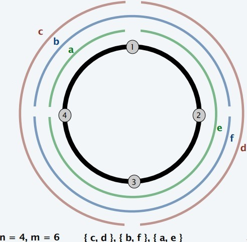

## Review: interval coloring

**Interval coloring (partitioning)**. Greedy algorithm finds coloring such that number of colors *equals* depth of schedule.

- **Depth**. Maximum number that pass over any single point on the time-line.

| c | c |  | d | d |  | f | f |  | j | j |
| --- | --- | --- | --- | --- | --- | --- | --- | --- | --- | --- |
| b | b | b | b | b |  | g | g |  | i | i |
| a | a |  | e | e | e | e | h | h | h | h |

**Circular arc coloring**.

- Weak duality: number of colors $\ge$ depth.
- Strong duality does not hold.

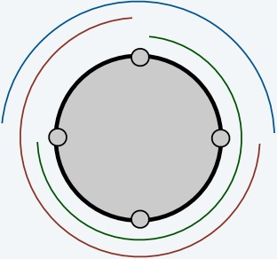

## (Almost) transforming coloring

**Circular arc coloring**. Given a set of $n$ arcs with depth $d \le k$, can the arcs be colored with $k$ colors?

**Equivalent problem**. Cut the network between nodes $v_1$ and $v_n$. The arcs can be colored with $k$ colors iff the intervals can be colored with $k$ colors in such a way that “sliced” arcs have the same color.

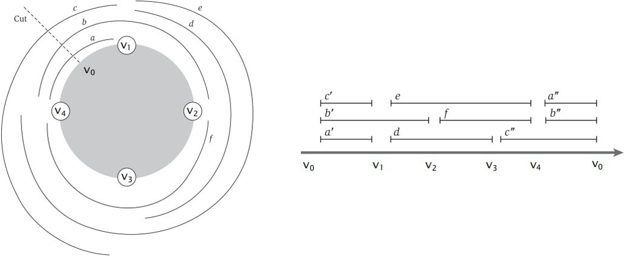

## Circular arc coloring: DP

**Dynamic programming algorithm**.

- Assign distinct color to each interval which begins at cut node $v_0$.
- At each node $v_i$, some intervals may finish, and others may begin.
  - Enumerate all $k$-colorings of the intervals through $v_i$ that are consistent with the colorings of the intervals through $v_{i–1}$.
- The arcs are $k$-colorable iff some coloring of intervals ending at cut node $v_0$ is consistent with original coloring of the same intervals.

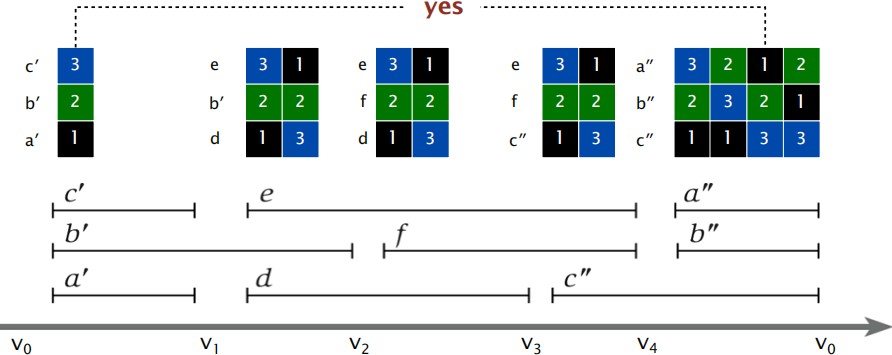

## Circular arc coloring: running time

**Running time**. $O(k! \cdot n)$.

- The algorithm has $n$ phases.
- Bottleneck in each phase is enumerating all consistent colorings.
- There are at most $k$ intervals through $v_i$, so there are at most $k!$ colorings to consider.

**Remark**. This algorithm is practical for small values of $k$ (say $k = 10$) even if the number of nodes $n$ (or paths) is large.

# Vertex cover in bipartite graphs

## Vertex cover

Given a graph $G = (V, E)$ and an integer $k$, is there a subset of vertices $S \subseteq V$ such that $| S | \le k$, and for each edge $(u, v)$ either $u \in S$ or $v \in S$ or both?

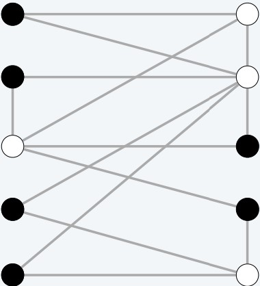

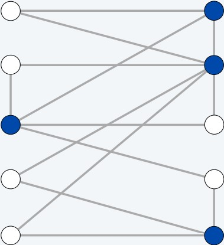

## Vertex cover and matching

**Weak duality**. Let $M$ be a matching, and let $S$ be a vertex cover. Then, $| M | ≤ | S |$.  
**Pf**. Each vertex can cover at most one edge in any matching.

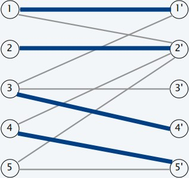

## König-Egerváry Theorem

**Theorem**. [König-Egerváry] In a *bipartite* graph, the max cardinality of a matching is equal to the min cardinality of a vertex cover.

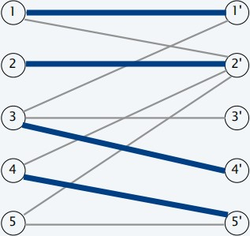

## König-Egerváry Theorem: proof

**Theorem**. [König-Egerváry] In a *bipartite* graph, the max cardinality of a matching is equal to the min cardinality of a vertex cover.

- Suffices to find matching $M$ and cover $S$ such that $| M | = | S |$.
- Formulate max flow problem as for bipartite matching.
- Let $M$ be max cardinality matching and let $(A, B)$ be min cut.

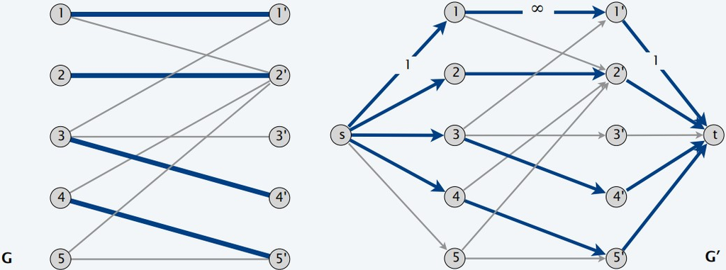

## König-Egerváry Theorem: proof (cont.)

**Theorem**. [König-Egerváry] In a *bipartite* graph, the max cardinality of a matching is equal to the min cardinality of a vertex cover.

- Suffices to find matching $M$ and cover $S$ such that $| M | = | S |$.
- Formulate max flow problem as for bipartite matching.
- Let $M$ be max cardinality matching and let $(A, B)$ be min cut.
- Define $L_A = L \cap A, L_B = L \cap B , R_A = R \cap A, R_B = R \cap B$.
- **Claim 1**. $S = L_B ∪ R_A$ is a vertex cover.
  - consider $(u, v) \in E$
  - $u \in L_A, v \in R_B$ impossible since infinite capacity
  - thus, either $u \in L_B$ or $v \in R_A$ or both
- **Claim 2**. $| M | = | S |$.
  - max-flow min-cut theorem $\Rightarrow | M | = cap(A, B)$
  - only edges of form $(s, u)$ or $(v, t)$ contribute to $cap(A, B)$
  - $| M | = cap(A, B) = | L_B | + | R_A | = | S |$.